# Strategies and Structures for Improving Data Use - An SEA Perspective

Presentation to the SDP Summer Institute for Leadership in Analytics August 6th-8th 2012

Jared Knowles, Policy Research Advisor at Wisconsin Department of Public Instruction

# The Big Questions

- How do extract meaning from administrative data systems?
- Can we do data analysis fast enough to inform decisions and improve outcomes?
- Can we produce analyses that are **approachable** to policy makers the public *so that they galvanize change*?
- Can we do this under time and capacity constraints in a way that is rigorous, valid, and accurate?

# Ask Jen

- Every agency has someone who gets these requests, and that someone is **overworked**

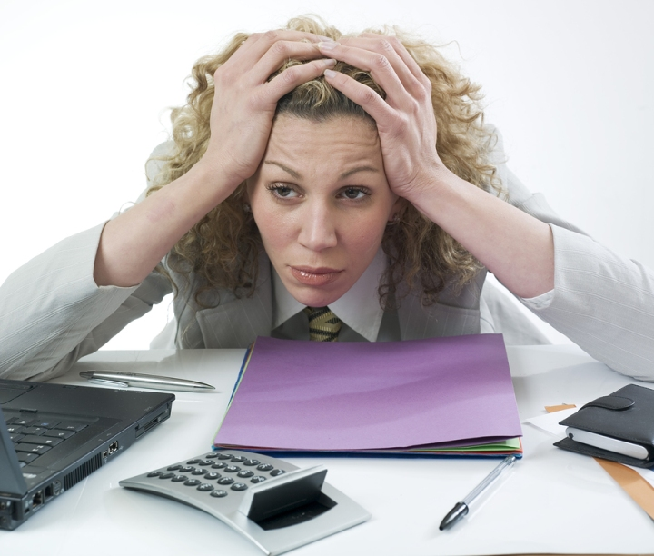

# The Problem?

- Jen doesn’t scale
- We don’t have enough Jen’s

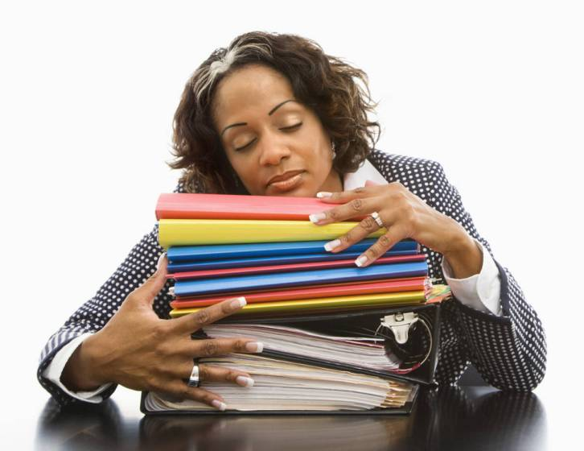

# Policy Relevant Research is the Answer

John Tukey said:

> An approximate answer to the right problem is worth a good deal more than the exact answer to an approximate problem
- This is what policy relevant research is about

# Fast

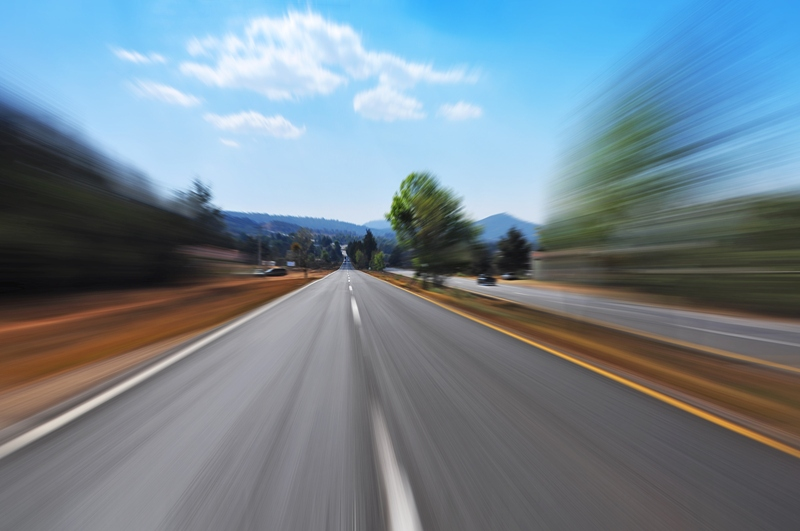

# Focused

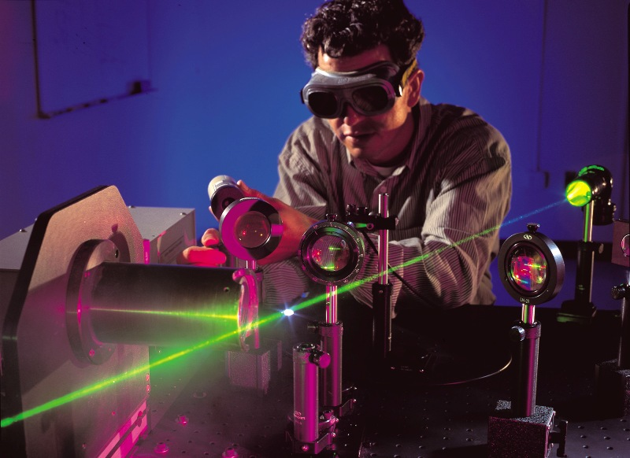

# Approximate

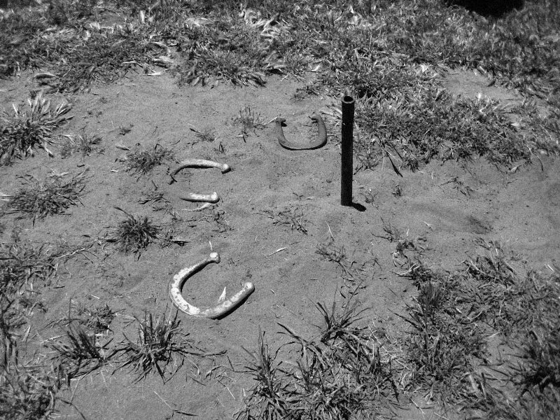

# Policy relevant research is everywhere

- COMPSTAT used by police departments around the world with an estimated 90% of large US police deparments implementing it http://www.policefoundation.org/pdf/growthofcompstat.pdf
- A/B testing at [Khan Academy](http://www.khanacademy.org/about/blog/post/22599533318/trying-out-new-features)
- Teaching is all about quick and focused research into what works through benchmark assessments and project management

# Quantitative Revolution within SEAs

# Data In

[figure not shown]

# Clean, reshape, and package

[figure not shown]

# Analyze and Inform Decisions

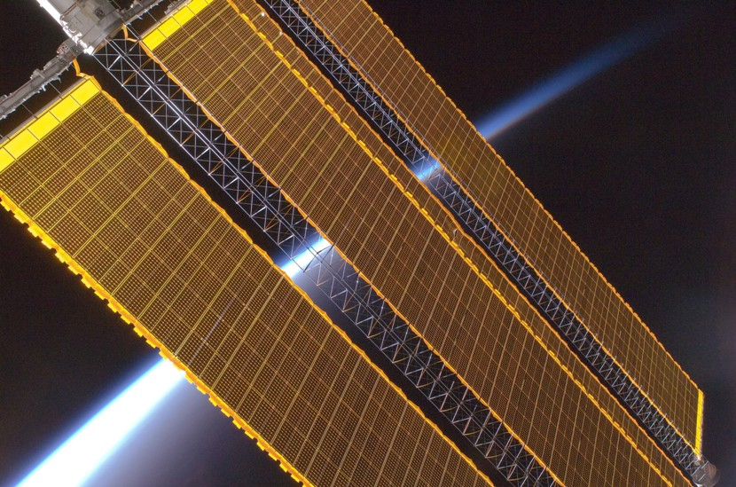

# How to do this?

- Everyone at an SEA has a ton of work and data analysis is often viewed as a luxury
- Additionally, work has to be done **efficiently**, **tranparently**, and **reproducibly** to be valid
- This is expensive in terms of time, money, and management resources
- What are some solutions?

# My Favorite

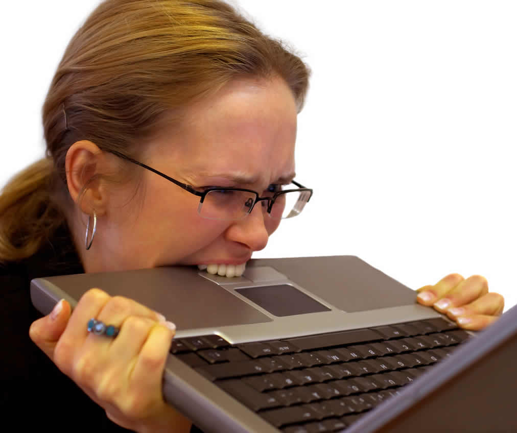

# Two Big Challenges

- Analyses that are done are done ad hoc and disconnected from a cohesive strategy
- They are **poorly documented**
- Done in disparate and proprietary toolsets
- Unable to be reproduced with updated data
- **Knowledge is lost, not accumulated**

# Jail

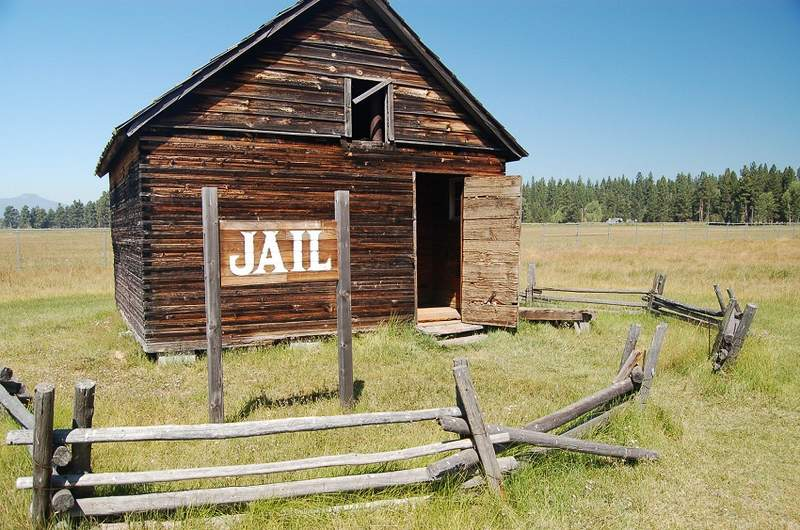

# Analyses Don’t Get Used

- One or two specific staff work on a project and may or may not be retained
- Staff turnover threatens the ability of the agency to utilize data because work cannot be effectively standardized and passed along
- New staff do not have a consistent practice to adopt

# Incoherence

[figure not shown]

# Wisconsin’s Solution

### R

[figure not shown]

# R is

- Free and open source
- Extensible
- Reproducible
- Scriptable
- Can be integrated into operational systems
- A gateway to learning statistics

# But wait…

## Isn’t R?

# Confusing?

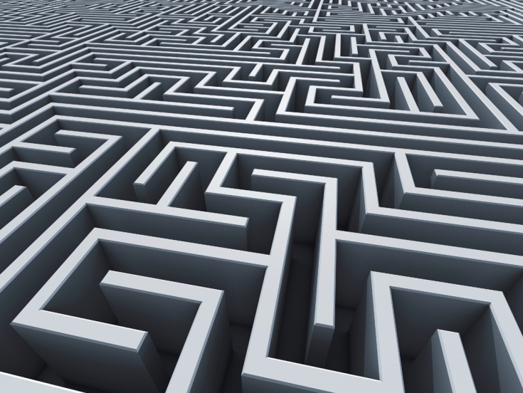

# Buggy?

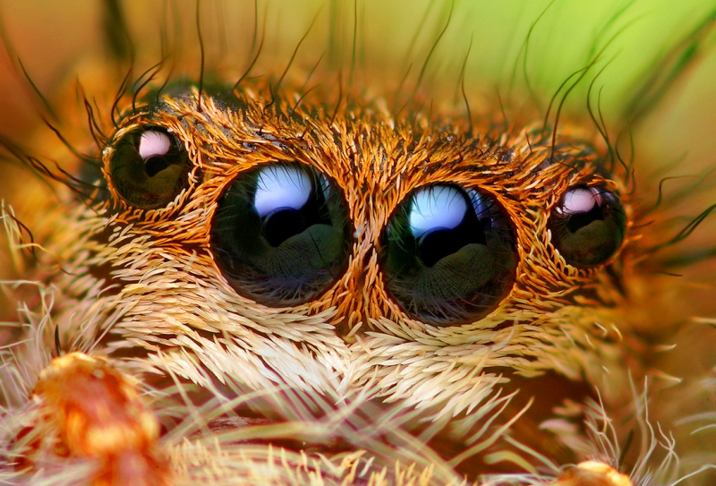

# How does Wisconsin use R?

- R is used to script repeated tasks and free up agency staff time for more policy research
- AYP, or accountability, is calculated using an R script that is reproducible, transparent, and fast!
- Other reports are being autmoated as well, and can continue through staff turnover
- Data quality can be standardized with basic data checking modules run before every report
- This leaves more time to do policy relevant research, which R has some great tools for

# Meet the Inference Tree

```r
library(partykit)
mypar <- ctree_control(testtype = "Bonferroni", mincriterion = 0.99)
mytree <- ctree(mathSS ~ race + econ + ell + disab + sch_fay + dist_fay + attday +
    readSS, data = subset(df, grade == 3))
plot(mytree)
```

[figure not shown]

# What is an inference tree?

- An inference tree isa way of dividing data into meaningful groups
- It is an algorithm that splits data by groups searching for the most meaningful and significant splits among grouping variables
- This is a way to identify meaningfully large groups with differing performance
- Useful for exploring policy opportunities

# How can it be used?

- A little R code
- A little explanation
- A good dataset with good variables that are meaningful
- The good news is most states have all of this!

# This is different than research

- First, it is using the population data for what it should be used for
- Second, it’s free and easy to implement
- Third, it’s useful for questions policy makers might be eager to know–where should we focus our limited resources?

# How else is Wisconsin using R?

- Script common processes like AYP and other reports
- Fit growth models
- Visualize data for policy makers
- Analyze all sorts of ad hoc data from different sources, and combine datasets for quick policy questions

# Thoughts

1. What are some ways inference trees could be used in your agency?
2. What types of analyses would be useful across district and state agencies?
3. Sharing work with common data is something we all have an interest in to understand our work. How can we make this happen?

# Attribution and License

This work (Data Analysis in an SEA, by Jared E. Knowles), in service of the [Wisconsin Department of Public Instruction](http://www.dpi.wi.gov), is free of known copyright restrictions.